# PM566 Midterm

```r
proportions_fruit <-  prop.table(table(pred$HDorAttack, pred$EatsFruits), margin = 2)



proportions_fruit %>%
  knitr::kable(caption="Proportion of Heart Disease by if they eat fruit") %>%
  kableExtra::kable_styling(bootstrap_options="striped",full_width=FALSE)
```

Proportion of Heart Disease by if they eat fruit

|  | No | Yes |
| --- | --- | --- |
| No | 0.8982022 | 0.910204 |
| Yes | 0.1017978 | 0.089796 |

The barplot show how vegetable eating status is distributed between Heart disease status. The heart disease seems to be less prevalent in individuals who eat vegetables showing that there might be an association between eating vegtebales and heart disease. The table below also shows that for the proportion of individuals with heart disease also were not eating vegetables.

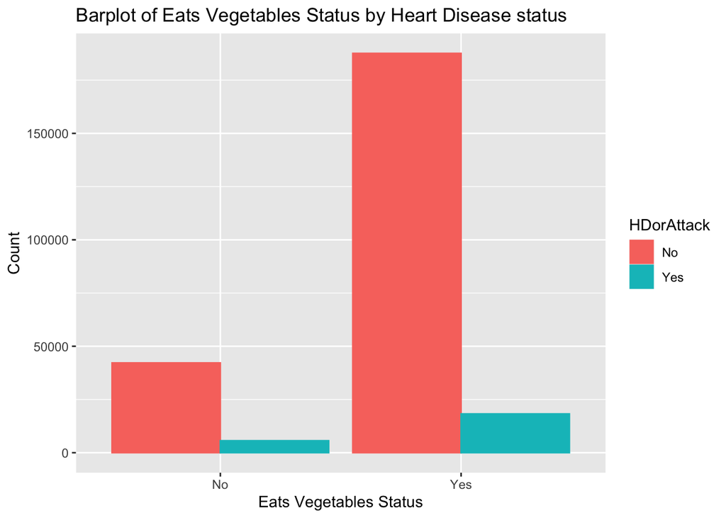

```r
ggplot(pred, aes(x = EatsVeggies, colour=HDorAttack,fill = HDorAttack)) +
  geom_bar(position = "dodge",stat="count") +
  labs(x = "Eats Vegetables Status", y = "Count",title="Barplot of Eats Vegetables Status by Heart Disease status")
```

```r
proportions_veg <-  prop.table(table(pred$HDorAttack, pred$EatsVeggies), margin = 2)



proportions_veg %>%
  knitr::kable(caption="Proportion of Heart Disease by if they eat vegetables ") %>%
  kableExtra::kable_styling(bootstrap_options="striped",full_width=FALSE)
```

Proportion of Heart Disease by if they eat vegetables

|  | No | Yes |
| --- | --- | --- |
| No | 0.8820837 | 0.9113296 |
| Yes | 0.1179163 | 0.0886704 |

The barplot show how diabetes status is distributed between Heart disease status. The heart disease seems to be less prevalent in individuals who do not have diabetes or are bordline showing that there might be an association between diabetes and heart disease. The table below also shows that for the proportion of individuals with heart disease also were diabetic.

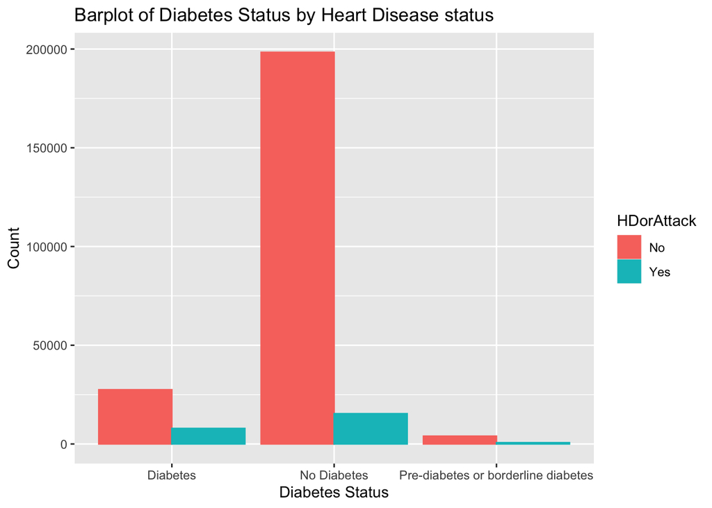

```r
ggplot(pred, aes(x = HasDiabetes, colour=HDorAttack,fill = HDorAttack)) +
  geom_bar(position = "dodge",stat="count") +
  labs(x = "Diabetes Status", y = "Count",title="Barplot of Diabetes Status by Heart Disease status")
```

```r
proportions_diabetes <-  prop.table(table(pred$HDorAttack, pred$HasDiabetes), margin = 2)



proportions_diabetes %>%
  knitr::kable(caption="Proportion of Heart Disease by Diabetes status") %>%
  kableExtra::kable_styling(bootstrap_options="striped",full_width=FALSE)
```

Proportion of Heart Disease by Diabetes status

|  | Diabetes | No Diabetes | Pre-diabetes or borderline diabetes |
| --- | --- | --- | --- |
| No | 0.7771176 | 0.9281667 | 0.8566184 |
| Yes | 0.2228824 | 0.0718333 | 0.1433816 |

CONCLUSION: As we expected the health indicators seemed to be associated with heart disease. For the most part all the variables that seem to put you in a healthier category showed a decrease in heart disease. Although, the data did seem to have an exception were we show that an increase in heavy use of alcohol showed a decrease in heart diease, but this trend need more research because the data might have been skewed due to small sample size in the heavy use alcohol category. All variables seemed to be associated with heart disease and deserve to be furthered studied, but from the list of variables of interest heavy use of alcohol and fruit eating status seemed to be the least associated between the variables.